# Resume

Benjamin Wolfe

2019-10-17

benjamin.e.wolfe@gmail.com  
202.709.6533

BENJAMIN WOLFE

linkedin.com/in/BenjaminWolfe [@BenjaminWolfe](https://twitter.com/BenjaminWolfe)

Analytics leader with 12 years experience. Curious learner, supportive manager, thoughtful problem solver,

articulate communicator, and champion of excellence in analytics. Looking to explore new challenges with you!

### Esurance

#### October 2011–current

*CoverageMyWay™*. Built a patent-pending, award-winning recommendation engine from concept through rollout in 43 states and oversaw the design and deployment of A/B tests. CoverageMyWay suggests coverage packages and add-ons in the online quote flow. Coordinated with disparate groups: product management, legal compliance, copywriting, UX design, dev, and QA.

*Management*. Led 2 teams consecutively over 6 years: one built from the ground up, one acquired; one managed in person, one remote. Hired and mentored 6 data scientists / analysts and cleared the way for 8 promotions. Established a bi-weekly “Analytics Masterclass” to learn from our work.

*Analytics Ecosystem*. Implemented [Heap Analytics](https://heap.io/) for existing customers’ clickstream traffic; defined metrics and advocated for usage among partners. Championed analytics best practices and tools: [Jira](https://www.atlassian.com/software/jira) for workflow management, [git](https://git-scm.com/) and [Bitbucket](https://bitbucket.org/product) for version control, full access to [Tableau Server](https://www.tableau.com/products/server) for dashboarding. Created an internal CX Analytics blog, a code cookbook, and an internal R package repository.

*Deep-Dives*. Analyzed issues of relevance to customers and CX stakeholders. What DOI regulations cause purchasers the most friction? What transactions are customers unable to complete themselves? How will upcoming rate activity affect customer loyalty? What can we do about it? Explored data, recommended KPIs, wrote ETL jobs, designed dashboards, shared learnings.

### Farmers Insurance Group

#### October 2006–October 2011

*Automated reporting*. Ran all recruitment and promotion tracking for regional marketing office. Work initially involved heavy Excel usage exclusively. Consolidated data back-end first to MS Access and then to MS SQL Server; automated repetitive tasks with VBA. Also consulted on nationwide projects.

*Agency and District Growth Dashboards*. This company-wide initiative gathered a host of previously disconnected KPIs into 360° views of the agent and district. I researched the data sources and providers, documented and conveyed findings to leadership, and orchestrated and coded all data flows.

#### Technical

- Expert: R, SQL, Tableau, Excel
- R: [tidyverse](https://www.tidyverse.org/), [devtools](https://devtools.r-lib.org/), [pkgdown](https://pkgdown.r-lib.org/), [blogdown](https://bookdown.org/yihui/blogdown/), [bookdown](https://bookdown.org/yihui/bookdown/), drat, [TravisCI](https://travis-ci.org/)
- SQL: T-SQL, PL/SQL, PostGreSQL, Redshift, Hadoop, Hive

#### Published Work

- [Signs](https://benjaminwolfe.github.io/signs/) (see [CRAN](https://cran.r-project.org/web/packages/signs)) solves a simple problem of mathematical typography

#### Other

- Languages: English (native), Spanish (fluent)
- [CliftonStrengths](https://www.gallup.com/cliftonstrengths): Learner, Maximizer, Input, Connectedness, Intellection

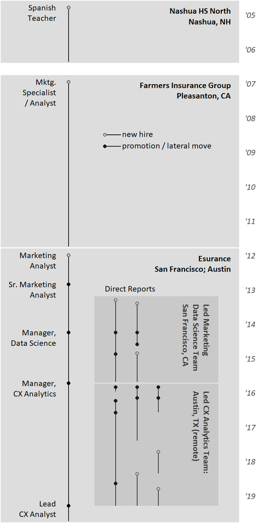

#### Education

- Wheaton College, Wheaton, Illinois
- Bachelor of Arts in Spanish and Philosophy
- Graduated with honors; advanced studies in Mexico

#### Patent Pending & Awards

Co-inventor: Apparatus & Method for Supplying Personalized Insurance Quotes. US Patent Application 14/681,931, filed April 8, 2015.

[CoverageMyWay](https://web.archive.org/web/20160218214238/https://blog.esurance.com/esurance-introduces-coverage-my-way/)™ was 1 of 8 [InformationWeek Elite 100 Business Innovation Award](https://www.informationweek.com/strategic-cio/executive-insights-and-innovation/esurance-puts-analytics-closer-to-the-customer/d/d-id/1319843) winners in 2015, and won Esurance a place in the Elite 100 in 2016 as well.